# Rocket Fuel Analysis

### Import Data

Import the rocketfuel CSV file and the load the required libraries.

```r
data <- read.csv('rocketfuel_deciles.csv')
library(psych)
library(ggplot2)
library(dplyr)
library(knitr)
```

### Exploring Data

We have 588101 rows of data and 7 columns.

```r
dim(data)
```

```
## [1] 588101      7
```

Take a look at our data. The column “test” equals to 1 means treatment group, 0 means control group. Treatment group was exposed to real ads, control group was shown a PSA. Converted column equals to 1 means a user purchase the bag during campaign, 0 means users didn’t purchase.Tot_impr means the total number of ad impressions the user encountered. Mode_impr_day shows the day of the week on which the user encountered the most number of impressions. Mode_impr_hour is similar to mode_impr_day, just change from day to hours. Tot_impr_decile labeling people into deciles (i.e., 10% groups) by tot_impr.

```r
head(data)
```

```
##   user_id test converted tot_impr mode_impr_day mode_impr_hour tot_impr_decile
## 1 1391842    1         0        2             3             19               2
## 2 1215269    1         0        1             4             12               1
## 3 1604030    1         0        2             6             11               2
## 4 1278452    1         0        1             7             18               1
## 5 1363432    1         0        1             6             13               1
## 6  909876    0         0        1             3             12               1
```

Create a table to see the numbers and shares of individuals who were in the treatment vs. control group. We could see that we have 4% of the data as control group and the rest is treatment group.

```r
tb_treatment_full <- matrix(NA,nrow=2,ncol = 2)
tb_treatment_full[1,] <- format(table(data$test),digit=0)
tb_treatment_full[2,] <- format(prop.table(table(data$test)),digit=3)
rownames(tb_treatment_full) <- c("Frequency","Proportion")
colnames(tb_treatment_full) <- c("Control","Treatment" )
kable(tb_treatment_full)
```

|  | Control | Treatment |
| --- | --- | --- |
| Frequency | 23524 | 564577 |
| Proportion | 0.04 | 0.96 |

### Calculate Means and Standard Deviations of Variables by Control and Treatment Group

We could see that the means and standard deviations between control and treatment group are really similar.

```r
summary = data %>%
  mutate(test = as.factor(test)) %>%
  group_by(test) %>%
  summarise(n = length(user_id),
            mean.conv = round(mean(converted),2),
            mean.tot_impr  = round(mean(tot_impr ),2),
            mean.impr_d = round(mean(mode_impr_day),2),
            mean.impr_h = round(mean(mode_impr_hour),2),

            sd.conv = round(sd(converted),3),
            sd.tot_impr  = round(sd(tot_impr ),3),
            sd.impr_d = round(sd(mode_impr_day),3),
            sd.impr_h = round(sd(mode_impr_hour),3))
kable(summary)
```

| test | n | mean.conv | mean.tot_impr | mean.impr_d | mean.impr_h | sd.conv | sd.tot_impr | sd.impr_d | sd.impr_h |
| --- | --- | --- | --- | --- | --- | --- | --- | --- | --- |
| 0 | 23524 | 0.02 | 24.76 | 3.95 | 14.30 | 0.132 | 42.861 | 1.949 | 4.656 |
| 1 | 564577 | 0.03 | 24.82 | 4.03 | 14.48 | 0.158 | 43.750 | 2.006 | 4.842 |

### Plot histograms of Variables by Control and Treatment Group

Looks like the distribution of variables is similar between control group and treatment group. Therefore, our data seems to be balanced, which would lead us to a more precise result.

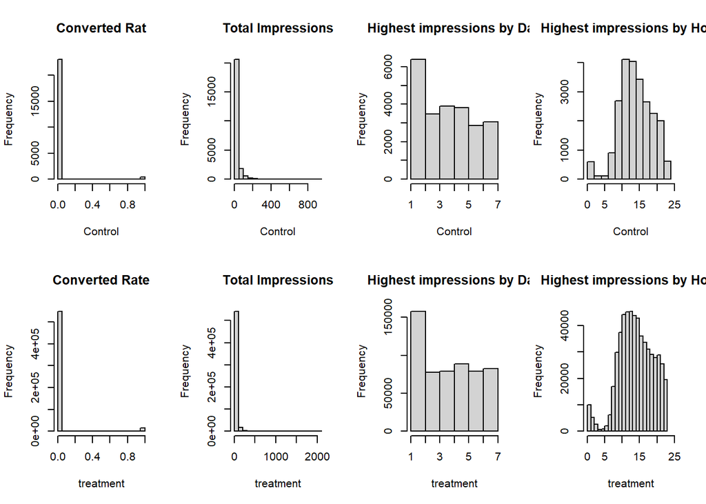

```r
attach(data)
par(mfrow=c(2,4))
hist(converted[test==0], main = paste("Converted Rat"), xlab = "Control")
hist(tot_impr[test==0], main = paste("Total Impressions"), xlab = "Control")
hist(mode_impr_day[test==0], main = paste("Highest impressions by Day"), xlab = "Control",breaks=6)
hist(mode_impr_hour[test==0], main = paste("Highest impressions by Hour"), xlab = "Control",xlim = c(0,25))

hist(converted[test==1], main = paste("Converted Rate"), xlab = "treatment")
hist(tot_impr[test==1], main = paste("Total Impressions"), xlab = "treatment")
hist(mode_impr_day[test==1], main = paste("Highest impressions by Day"), xlab = "treatment",breaks=6)
hist(mode_impr_hour[test==1], main = paste("Highest impressions by Hour"), xlab = "treatment",xlim = c(0,25))
```

```r
detach(data)
par(mfrow=c(1,1))
```

### Calculate Means, Standard Errors, Confidence Intervals of Variables by Control and Treatment Group

I calculated another table of means, standard errors, confidence intervals of variables because we will need these figures to draw our following graphs. In addition, we could notice that the confidence interval of control group is much wider than treatment group, this is probably because much smaller sample size. We will visualize this in next graph.

```r
summary2 = data %>%
  mutate(test = as.factor(test)) %>%
  group_by(test) %>%
  summarise(n = length(user_id),
            mean.conv = round(mean(converted),4),
            mean.tot_impr  = round(mean(tot_impr ),4),
            mean.impr_d = round(mean(mode_impr_day),4),
            mean.impr_h = round(mean(mode_impr_hour),4),

            error.conv = round(sd(converted)/sqrt(n),4),
            error.tot_impr  = round(sd(tot_impr )/sqrt(n),4),
            error.impr_d = round(sd(mode_impr_day)/sqrt(n),4),
            error.impr_h = round(sd(mode_impr_hour)/sqrt(n),4),

            LCI.conv = round(mean.conv - 1.96*error.conv,4),
            LCI.tot_impr  = round(mean.tot_impr  - 1.96*error.tot_impr ,4),
            LCI.impr_d = round(mean.impr_d - 1.96*error.impr_d,4),
            LCI.impr_h = round(mean.impr_h - 1.96*error.impr_h,4),

            UCI.conv = round(mean.conv + 1.96*error.conv,4),
            #repeat for calls
            UCI.tot_impr  = round(mean.tot_impr + 1.96*error.tot_impr ,4),
            UCI.impr_d = round(mean.impr_d+ 1.96*error.impr_d,4),
            UCI.impr_h = round(mean.impr_h+ 1.96*error.impr_h,4))
kable(summary2)
```

| test | n | mean.conv | mean.tot_impr | mean.impr_d | mean.impr_h | error.conv | error.tot_impr | error.impr_d | error.impr_h | LCI.conv | LCI.tot_impr | LCI.impr_d | LCI.impr_h | UCI.conv | UCI.tot_impr | UCI.impr_d | UCI.impr_h |
| --- | --- | --- | --- | --- | --- | --- | --- | --- | --- | --- | --- | --- | --- | --- | --- | --- | --- |
| 0 | 23524 | 0.0179 | 24.7611 | 3.9526 | 14.3049 | 9e-04 | 0.2794 | 0.0127 | 0.0304 | 0.0161 | 24.2135 | 3.9277 | 14.2453 | 0.0197 | 25.3087 | 3.9775 | 14.3645 |
| 1 | 564577 | 0.0255 | 24.8234 | 4.0286 | 14.4759 | 2e-04 | 0.0582 | 0.0027 | 0.0064 | 0.0251 | 24.7093 | 4.0233 | 14.4634 | 0.0259 | 24.9375 | 4.0339 | 14.4884 |

### Plot Means and Confidence Interevals of Converted Rate by Control and Treatment Groups

The Y-axis is converted rate, X-axis is control or treatment group. As we mentioned above, we could clearly observe that control group has a much wider confidence interval. It makes sense since treatment group has a really large sample size. We could also observe that our treatment seems to have positive impact on converted rate.

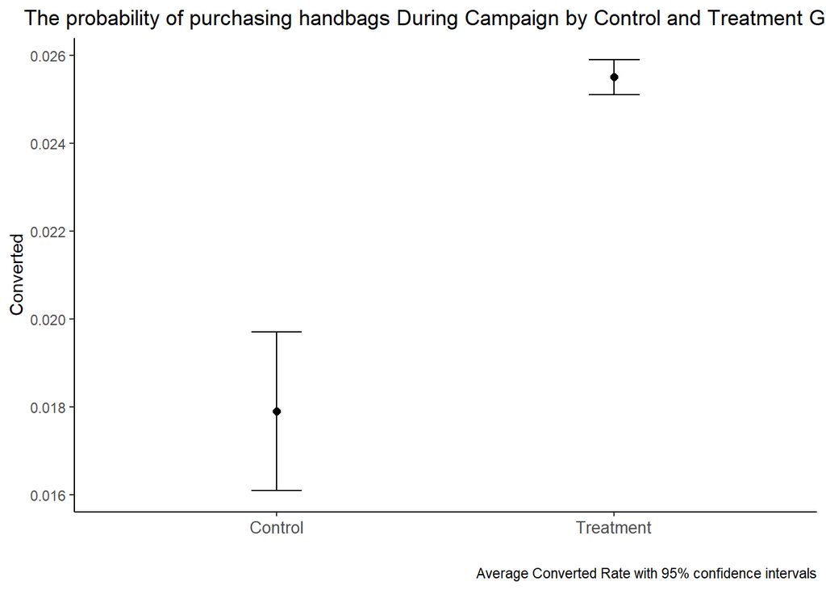

```r
summary2 %>%
  ggplot(aes(x=test)) +
  geom_point(aes(y = mean.conv), size = 2) +
  scale_shape_manual(values=c(15, 16)) +
  labs(
    title = "The probability of purchasing handbags During Campaign by Control and Treatment Group",
    caption = "Average Converted Rate with 95% confidence intervals"
  )+
  ylab("Converted") +
  scale_x_discrete(labels=c("0" = "Control", "1" = "Treatment")) +
  xlab("")+
  theme(panel.grid.major = element_blank(), panel.grid.minor = element_blank(),
        panel.background = element_blank(),axis.line = element_line(colour = "black"),
        axis.text.x= element_text(size = 10), legend.position=c(.5,.5),
        plot.title=element_text(hjust=.5))+
  geom_errorbar(aes(ymin = LCI.conv,
                    ymax = UCI.conv), width = .15)+
  scale_color_manual(values=c("darkgrey","black"))
```

### Calculate ATE and CI For Treatment

I create a table to calculate ATE and CI for treatment. We could see that our treatment has a relatively low effect on converted rate. However, our confidence interval is tight, so we have confident that the treatment has a positive impact on converted rate, but the impact seems small.

```r
ATE <-matrix(NA, nrow = 4, ncol = 4)
colnames(ATE) <- c("Control Mean", "Treatment ATE", "LCI Treatment", "UCI Treatment")
rownames(ATE) <- c("converted", "tot_impr", "mode_impr_day","mode_impr_hour")

mean.control <- t(summary2[1,3:6])
mean.treat1 <- t(summary2[2,3:6])
ATE[,1] <- mean.control
ATE[,2] <- effect.treat1 <- mean.treat1-mean.control  #


sd.control <- t(summary2[1,7:10])
sd.treat1 <- t(summary2[2,7:10])

error.treat1 <- sqrt(sd.control^2+sd.treat1^2)

ATE[,3]<-LCI.treat1 <- round(effect.treat1 -1.96*error.treat1,4)
ATE[,4]<-UCI.treat1 <- round(effect.treat1 +1.96*error.treat1,4)
kable(ATE)
```

|  | Control Mean | Treatment ATE | LCI Treatment | UCI Treatment |
| --- | --- | --- | --- | --- |
| converted | 0.0179 | 0.0076 | 0.0058 | 0.0094 |
| tot_impr | 24.7611 | 0.0623 | -0.4971 | 0.6217 |
| mode_impr_day | 3.9526 | 0.0760 | 0.0506 | 0.1014 |
| mode_impr_hour | 14.3049 | 0.1710 | 0.1101 | 0.2319 |

### Using the Regression Approach to Estimate Average Treatment Effects

We try to use regression approach to calculate our ATE. We could see that the result we get is very similar to the ATE we obtained in the last section.

```r
data$treatment <- as.numeric(data$test == 1)
data$control <- as.numeric(data$test == 0)
library("lmtest")
library("sandwich")

fit.converted <- lm(converted~treatment+control, data = data)
#coeftest(fit.converted, vcov = vcovHC(fit.converted, type = "HC3"))
coefci(fit.converted, vcov = vcovHC(fit.converted))
```

```
##                   2.5 %      97.5 %
## (Intercept) 0.016161839 0.019546374
## treatment   0.005950859 0.009434048
```

```r
fit.tot_impr<- lm(tot_impr~treatment+control, data = data)
#coeftest(fit.tot_impr, vcov = vcovHC(fit.tot_impr, type = "HC3"))
coefci(fit.tot_impr, vcov = vcovHC(fit.tot_impr))
```

```
##                  2.5 %     97.5 %
## (Intercept) 24.2134132 25.3088620
## treatment   -0.4972596  0.6217147
```

```r
fit.mode_impr_day<- lm(mode_impr_day~treatment+control, data = data)
#coeftest(fit.mode_impr_day, vcov = vcovHC(fit.mode_impr_day, type = "HC3"))
coefci(fit.mode_impr_day, vcov = vcovHC(fit.mode_impr_day))
```

```
##                  2.5 %    97.5 %
## (Intercept) 3.92773824 3.9775500
## treatment   0.05047622 0.1013757
```

```r
fit.mode_impr_hour<- lm(mode_impr_hour~treatment+control, data = data)
#coeftest(fit.mode_impr_hour, vcov = vcovHC(fit.mode_impr_hour, type = "HC3"))
coefci(fit.mode_impr_hour, vcov = vcovHC(fit.mode_impr_hour))
```

```
##                  2.5 %     97.5 %
## (Intercept) 14.2454198 14.3644255
## treatment    0.1101486  0.2318055
```

### Heterogeneous Treatment Effects

Create a summary table showing the sample size, the mean and the standard deviation of variables in the data set for both treatment and control group over the 10 deciles of total impressions. This heterogeneous treatment effects might be caused by sub-groups.

```r
attach(data)
tb_outcomes <- matrix(NA, nrow = 9, ncol = 11)
rownames(tb_outcomes) <- c("converted.mean", "tot_impr.mean", "mode_impr_day.mean","mode_impr_hour.mean","converted.sd", "tot_impr.sd", "mode_impr_day.sd","mode_impr_hour.sd","All variables size") # name the rows
colnames(tb_outcomes) <- c("Full Sample", "decile1", "decile2","decile3","decile4","decile5","decile6","decile7","decile8","decile9","decile10") # name the columns

tb_outcomes[1:4,1] <- t(round(c(mean(converted),mean(tot_impr),mean(mode_impr_day),mean(mode_impr_hour)),2))
tb_outcomes[5:8,1] <- t(round(c(sd(converted),sd(tot_impr),sd(mode_impr_day),sd(mode_impr_hour)),2))
tb_outcomes[9,1] <- dim(data)[1]
tb_outcomes[1:4,2:11] <- t(aggregate(data[,3:6],by = list(tot_impr_decile),mean)[,2:5])
tb_outcomes[5:8,2:11] <- t(aggregate(data[,3:6],by = list(tot_impr_decile),sd)[,2:5])
tb_outcomes[9,2:11] <- t(round(aggregate(data[,3],by = list(tot_impr_decile),length)[,2],2))
kable(tb_outcomes)
```

|  | Full Sample | decile1 | decile2 | decile3 | decile4 | decile5 | decile6 | decile7 | decile8 | decile9 | decile10 |
| --- | --- | --- | --- | --- | --- | --- | --- | --- | --- | --- | --- |
| converted.mean | 0.03 | 1.572300e-03 | 2.555200e-03 | 3.508500e-03 | 4.270500e-03 | 6.827000e-03 | 7.796600e-03 | 1.298520e-02 | 2.263010e-02 | 5.172650e-02 | 1.433868e-01 |
| tot_impr.mean | 24.82 | 1.000000e+00 | 2.418482e+00 | 4.555728e+00 | 6.874071e+00 | 1.104253e+01 | 1.554645e+01 | 2.085008e+01 | 2.857335e+01 | 4.338457e+01 | 1.184641e+02 |
| mode_impr_day.mean | 4.03 | 4.082217e+00 | 3.911693e+00 | 3.940981e+00 | 3.965443e+00 | 3.971758e+00 | 4.074559e+00 | 4.088355e+00 | 4.120218e+00 | 4.099835e+00 | 4.025398e+00 |
| mode_impr_hour.mean | 14.47 | 1.441050e+01 | 1.441439e+01 | 1.454746e+01 | 1.459743e+01 | 1.453585e+01 | 1.449880e+01 | 1.444427e+01 | 1.436326e+01 | 1.446249e+01 | 1.441075e+01 |
| converted.sd | 0.16 | 3.962100e-02 | 5.048470e-02 | 5.912920e-02 | 6.521000e-02 | 8.234360e-02 | 8.795440e-02 | 1.132112e-01 | 1.487225e-01 | 2.214761e-01 | 3.504700e-01 |
| tot_impr.sd | 43.72 | 0.000000e+00 | 4.933137e-01 | 4.968894e-01 | 8.111544e-01 | 1.413109e+00 | 1.062642e+00 | 2.106842e+00 | 2.646907e+00 | 6.830868e+00 | 9.048044e+01 |
| mode_impr_day.sd | 2.00 | 1.955558e+00 | 2.011139e+00 | 1.986844e+00 | 1.987831e+00 | 2.007402e+00 | 2.015862e+00 | 2.022781e+00 | 2.012976e+00 | 2.012709e+00 | 2.008338e+00 |
| mode_impr_hour.sd | 4.83 | 5.115188e+00 | 4.875769e+00 | 4.784222e+00 | 4.730087e+00 | 4.772660e+00 | 4.743095e+00 | 4.779233e+00 | 4.843947e+00 | 4.846425e+00 | 4.848715e+00 |
| All variables size | 588101.00 | 5.660600e+04 | 6.848800e+04 | 5.272900e+04 | 5.854100e+04 | 6.313200e+04 | 5.810200e+04 | 6.453500e+04 | 4.909400e+04 | 5.942800e+04 | 5.744600e+04 |

This table might look a bit complicated, but let’s just focus on converted rate. We could see that before decile 8, our converted rate seems to gradually become larger but the difference is really small. Until decile 8 the slope becomes larger, the converted rate starts to increase more.

### Calculating Converted rate and Confidence Intervals by Treatment, Control Groups and Deciles

Calculating convert rate and confidence intervals, we will use these numbers to plot the following graph.

```r
summary3 = data %>%
  mutate(test = as.factor(test)) %>%
  mutate(decile = as.factor(tot_impr_decile)) %>%
  group_by(test,decile) %>%
  summarise(n = length(user_id),
            m.converted = mean(converted),
            e.converted = sd(converted)/sqrt(n),
            Lci.converted = m.converted - 1.96*e.converted,
            Uci.converted = m.converted + 1.96*e.converted,
            )
kable(summary3)
```

| test | decile | n | m.converted | e.converted | Lci.converted | Uci.converted |
| --- | --- | --- | --- | --- | --- | --- |
| 0 | 1 | 2308 | 0.0012998 | 0.0007501 | -0.0001704 | 0.0027701 |
| 0 | 2 | 3249 | 0.0021545 | 0.0008136 | 0.0005599 | 0.0037491 |
| 0 | 3 | 2304 | 0.0052083 | 0.0014999 | 0.0022685 | 0.0081482 |
| 0 | 4 | 2490 | 0.0056225 | 0.0014987 | 0.0026850 | 0.0085600 |
| 0 | 5 | 2250 | 0.0066667 | 0.0017160 | 0.0033034 | 0.0100299 |
| 0 | 6 | 1734 | 0.0080738 | 0.0021497 | 0.0038604 | 0.0122872 |
| 0 | 7 | 2662 | 0.0138993 | 0.0022695 | 0.0094511 | 0.0183476 |
| 0 | 8 | 1868 | 0.0198073 | 0.0032247 | 0.0134868 | 0.0261278 |
| 0 | 9 | 2234 | 0.0344673 | 0.0038605 | 0.0269008 | 0.0420339 |
| 0 | 10 | 2425 | 0.0841237 | 0.0056378 | 0.0730736 | 0.0951738 |
| 1 | 1 | 54298 | 0.0015839 | 0.0001707 | 0.0012494 | 0.0019183 |
| 1 | 2 | 65239 | 0.0025751 | 0.0001984 | 0.0021862 | 0.0029641 |
| 1 | 3 | 50425 | 0.0034308 | 0.0002604 | 0.0029205 | 0.0039412 |
| 1 | 4 | 56051 | 0.0042105 | 0.0002735 | 0.0036744 | 0.0047465 |
| 1 | 5 | 60882 | 0.0068329 | 0.0003339 | 0.0061785 | 0.0074873 |
| 1 | 6 | 56368 | 0.0077881 | 0.0003703 | 0.0070624 | 0.0085138 |
| 1 | 7 | 61873 | 0.0129459 | 0.0004545 | 0.0120551 | 0.0138366 |
| 1 | 8 | 47226 | 0.0227417 | 0.0006860 | 0.0213971 | 0.0240863 |
| 1 | 9 | 57194 | 0.0524006 | 0.0009318 | 0.0505743 | 0.0542269 |
| 1 | 10 | 55021 | 0.1459988 | 0.0015054 | 0.1430483 | 0.1489493 |

I subtract the treatment group with control group by deciles. We could see that converted rate fluctuates before decile 8, but after decile 8. Our treatment seems to have a larger impact on converted rate.

```r
summary3[11:20,4] - summary3[1:10,4]
```

```
##      m.converted
## 1   0.0002840254
## 2   0.0004206377
## 3  -0.0017774955
## 4  -0.0014120388
## 5   0.0001662232
## 6  -0.0002857110
## 7  -0.0009534508
## 8   0.0029344296
## 9   0.0179332783
## 10  0.0618750891
```

### Plot Means, Confidence Intervals of Converted Rate by Control/Treatment Group and Deciles

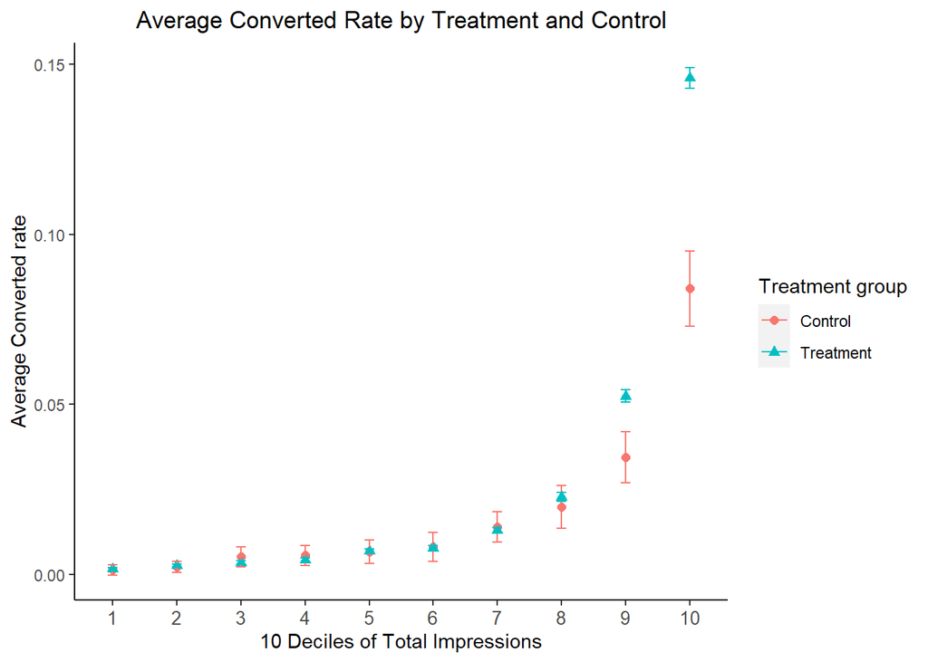

```r
summary3 %>%
  ggplot(aes(decile)) +
  geom_point(aes(y = m.converted, shape = test, color = test), size = 2) +
  geom_errorbar(aes(ymin = Lci.converted,
                    ymax = Uci.converted, color=test), width = .15)+
  ggtitle("Average Converted Rate by Treatment and Control") +
  ylab("Average Converted rate") + xlab("10 Deciles of Total Impressions") +
  theme(panel.grid.major = element_blank(), panel.grid.minor = element_blank(),
        panel.background = element_blank(),axis.line = element_line(colour = "black"),
        axis.text.x= element_text(size = 10),
        plot.title=element_text(hjust=.5) ) +
  scale_shape_discrete(name = "Treatment group", labels = c("Control", "Treatment"))+
  scale_color_discrete(name = "Treatment group", labels = c("Control",  "Treatment"))
```

```r
detach(data)
```